# MD Ch. 3-4 Homework

Samuel Snelson

2022-09-09

# Chapter 3

```r
library(tidyverse)
theme_set(theme_light(base_family = "Avenir"))
```

Importing Mario kart world record dataset.

```r
mario_kart <- read_csv("https://raw.githubusercontent.com/NicolasRestrep/223_course/main/Data/world_records.csv")
glimpse(mario_kart)
```

```
## Rows: 2,334
## Columns: 9
## $ track           <chr> "Luigi Raceway", "Luigi Raceway", "Luigi Raceway", "Lu…
## $ type            <chr> "Three Lap", "Three Lap", "Three Lap", "Three Lap", "T…
## $ shortcut        <chr> "No", "No", "No", "No", "No", "No", "No", "No", "No", …
## $ player          <chr> "Salam", "Booth", "Salam", "Salam", "Gregg G", "Rocky …
## $ system_played   <chr> "NTSC", "NTSC", "NTSC", "NTSC", "NTSC", "NTSC", "NTSC"…
## $ date            <date> 1997-02-15, 1997-02-16, 1997-02-16, 1997-02-28, 1997-…
## $ time_period     <chr> "2M 12.99S", "2M 9.99S", "2M 8.99S", "2M 6.99S", "2M 4…
## $ time            <dbl> 132.99, 129.99, 128.99, 126.99, 124.51, 122.89, 122.87…
## $ record_duration <dbl> 1, 0, 12, 7, 54, 0, 0, 27, 0, 64, 3, 0, 90, 132, 1, 74…
```

## Question 1

```r
three_laps <- mario_kart %>%
  filter(type == "Three Lap")
```

Datasets with and without the Rainbow Road track:

```r
three_without_rainbow <- three_laps %>%
  filter(track != "Rainbow Road")

three_only_rainbow <- three_laps %>%
  filter(track == "Rainbow Road")
```

## Question 2

Summary statistics for races at Rainbow Road and all other tracks

```r
rainbow_summary <- three_only_rainbow %>%
  summarize(mean = mean(time), std_dev = sd(time))

rainbow_summary
```

```
## # A tibble: 1 × 2
##    mean std_dev
##   <dbl>   <dbl>
## 1  276.    91.8
```

```r
all_other_summary <- three_without_rainbow %>%
  summarize(mean = mean(time), std_dev = sd(time))

all_other_summary
```

```
## # A tibble: 1 × 2
##    mean std_dev
##   <dbl>   <dbl>
## 1  114.    53.0
```

**The average time to complete a race is considerably longer on Rainbow Road that on every other track. That the standard deviation for Rainbow Road is larger than that of all others (grouped together) suggests that the difference in means isn’t due to variability in completion times on other tracks but that Rainbow Road is just longer and/or harder to finish.**

## Question 3

Grouping records by track

```r
#Grouped by track, producing summary stats on the number of records for each track
summary_by_track <- three_laps %>%
  group_by(track) %>%
  summarize(mean = mean(time), std_dev = sd(time), n_records = n()) %>%
  arrange(desc(n_records))

summary_by_track
```

```
## # A tibble: 16 × 4
##    track                  mean std_dev n_records
##    <chr>                 <dbl>   <dbl>     <int>
##  1 Toad's Turnpike       122.    56.7        124
##  2 Rainbow Road          276.    91.8         99
##  3 Frappe Snowland        77.1   48.2         92
##  4 D.K.'s Jungle Parkway 101.    52.3         86
##  5 Choco Mountain         95.2   30.2         84
##  6 Mario Raceway          79.1   13.0         82
##  7 Luigi Raceway         104.    27.1         81
##  8 Royal Raceway         158.    24.0         77
##  9 Yoshi Valley           82.7   33.2         74
## 10 Kalimari Desert       126.     2.34        73
## 11 Sherbet Land          116.     5.23        73
## 12 Wario Stadium         214.   100.          71
## 13 Koopa Troopa Beach     96.6    1.48        56
## 14 Banshee Boardwalk     126.     2.18        55
## 15 Moo Moo Farm           88.4    2.15        44
## 16 Bowser's Castle       134.     2.05        40
```

**While perhaps an odd metric, Toad’s Turnpike has had the most records set on it with 124 (in whatever period of time and scope of record keeping it refers to).**

## Question 4

Players who have multiple records on the same track(s)

```r
# Grouped by player and track, finding the number of records each player has on each track
player_records <- three_laps %>%
  group_by(player, track) %>%
  summarize(n_records = n()) %>%
  arrange(desc(n_records))
player_records
```

```
## # A tibble: 306 × 3
## # Groups:   player [60]
##    player   track                 n_records
##    <chr>    <chr>                     <int>
##  1 Penev    Choco Mountain               26
##  2 Lacey    D.K.'s Jungle Parkway        24
##  3 abney317 Rainbow Road                 21
##  4 MR       Toad's Turnpike              20
##  5 MR       Frappe Snowland              18
##  6 Penev    Toad's Turnpike              18
##  7 abney317 Kalimari Desert              16
##  8 MR       Sherbet Land                 16
##  9 abney317 Choco Mountain               15
## 10 abney317 Toad's Turnpike              15
## # … with 296 more rows
```

**It appears that Penev holds the most records established with 26 on Choco Mountain - quite a way to spend one’s time.**

## Question 5

Average time for each track

```r
# Grouped by track, finding average time it takes to finish race on each track
average_times <- three_laps %>%
  group_by(track) %>%
  summarize(avg_time = mean(time)) %>%
  arrange(desc(avg_time))

average_times
```

```
## # A tibble: 16 × 2
##    track                 avg_time
##    <chr>                    <dbl>
##  1 Rainbow Road             276.
##  2 Wario Stadium            214.
##  3 Royal Raceway            158.
##  4 Bowser's Castle          134.
##  5 Kalimari Desert          126.
##  6 Banshee Boardwalk        126.
##  7 Toad's Turnpike          122.
##  8 Sherbet Land             116.
##  9 Luigi Raceway            104.
## 10 D.K.'s Jungle Parkway    101.
## 11 Koopa Troopa Beach        96.6
## 12 Choco Mountain            95.2
## 13 Moo Moo Farm              88.4
## 14 Yoshi Valley              82.7
## 15 Mario Raceway             79.1
## 16 Frappe Snowland           77.1
```

**Surprise, Surprise, the track with the highest average time is Rainbow Road with 276 (I presume) seconds.**

Best time for each track

```r
# grouped by track, best (minimum) time it takes to complete race
best_times <- three_laps %>%
  group_by(track) %>%
  summarize(best_time = min(time)) %>%
  arrange(best_time) %>%
  select(track, best_time)

best_times
```

```
## # A tibble: 16 × 2
##    track                 best_time
##    <chr>                     <dbl>
##  1 Wario Stadium              14.6
##  2 Choco Mountain             17.3
##  3 D.K.'s Jungle Parkway      21.4
##  4 Frappe Snowland            23.6
##  5 Luigi Raceway              25.3
##  6 Toad's Turnpike            30.3
##  7 Yoshi Valley               33.4
##  8 Rainbow Road               50.4
##  9 Mario Raceway              58.5
## 10 Moo Moo Farm               85.9
## 11 Sherbet Land               91.6
## 12 Koopa Troopa Beach         95.2
## 13 Royal Raceway             119.
## 14 Kalimari Desert           122.
## 15 Banshee Boardwalk         124.
## 16 Bowser's Castle           132
```

**The fasted record is 14.6 (presumably) seconds set on Wario Stadium. We could see who set the record by simply selecting for player in addition to the track and time.**

## Question 6

Creating a new variable for records lasting longer or shorter than 100 days before being usurped!

```r
three_laps <- three_laps %>%
  mutate(lasting_record = if_else(record_duration > 100, 1, 0))

three_laps
```

```
## # A tibble: 1,211 × 10
##    track   type  short…¹ player syste…² date       time_…³  time recor…⁴ lasti…⁵
##    <chr>   <chr> <chr>   <chr>  <chr>   <date>     <chr>   <dbl>   <dbl>   <dbl>
##  1 Luigi … Thre… No      Salam  NTSC    1997-02-15 2M 12.…  133.       1       0
##  2 Luigi … Thre… No      Booth  NTSC    1997-02-16 2M 9.9…  130.       0       0
##  3 Luigi … Thre… No      Salam  NTSC    1997-02-16 2M 8.9…  129.      12       0
##  4 Luigi … Thre… No      Salam  NTSC    1997-02-28 2M 6.9…  127.       7       0
##  5 Luigi … Thre… No      Gregg… NTSC    1997-03-07 2M 4.5…  125.      54       0
##  6 Luigi … Thre… No      Rocky… NTSC    1997-04-30 2M 2.8…  123.       0       0
##  7 Luigi … Thre… No      Launs… NTSC    1997-04-30 2M 2.8…  123.       0       0
##  8 Luigi … Thre… No      Launs… NTSC    1997-04-30 2M 2.7…  123.      27       0
##  9 Luigi … Thre… No      Launs… NTSC    1997-05-27 2M 2.2…  122.       0       0
## 10 Luigi … Thre… No      Launs… NTSC    1997-05-27 2M 2.2…  122.      64       0
## # … with 1,201 more rows, and abbreviated variable names ¹shortcut,
## #   ²system_played, ³time_period, ⁴record_duration, ⁵lasting_record
```

```r
three_laps <- three_laps %>%
  group_by(player) %>%
  summarize(n_records = sum(lasting_record)) %>%
  arrange(desc(n_records))
```

## Question 7

Merging where players are from onto record data

```r
drivers <- read_csv("/Users/samuelsnelson/PhD Materials /Year One /Fall 2022/Statistics/soc_722/Data /drivers.csv")
head(drivers)
```

```
## # A tibble: 6 × 6
##   position player total  year records nation
##      <dbl> <chr>  <dbl> <dbl>   <dbl> <chr>
## 1        1 Penev    344  1997      NA Australia
## 2        1 Penev    344  1998     181 Australia
## 3        1 Penev    344  1999     126 Australia
## 4        1 Penev    344  2000      14 Australia
## 5        1 Penev    344  2001       5 Australia
## 6        1 Penev    344  2002      11 Australia
```

```r
head(three_laps)
```

```
## # A tibble: 6 × 2
##   player   n_records
##   <chr>        <dbl>
## 1 MR              81
## 2 MJ              50
## 3 Penev           27
## 4 abney317        26
## 5 VAJ             26
## 6 Zwartjes        24
```

```r
three_laps_country <- left_join(three_laps, drivers, by = "player")
```

[figure not shown]

```r
records_by_country <- three_laps_country %>%
  group_by(nation) %>%
  summarize(n_records = n()) %>%
  arrange(n_records) %>%
  drop_na() %>%
  ggplot(aes(reorder(nation, n_records),
             n_records)) +
  geom_bar(stat = "identity", color = "steelblue", fill = "steelblue") +
  labs(title = "Three-Lap Mario Kart Race World Records Across Country", x = "Country", y = "Number of Records Held", caption = "Note: Data represents records held for longer than 100 days.") +
  scale_y_continuous(breaks = seq(0, 650, by = 50))

records_by_country
```

```r
# I don't entirely like how this looks. The vertical scaling is okay. (1) The 0 value above the x axis (2) and the plot background would be better simpler
```

# Chapter 4

We’ve already got tidyverse loaded so let’s get crack-a-lackin.

## Question 1

```r
nfl_salary <- read_csv("https://raw.githubusercontent.com/NicolasRestrep/223_course/main/Data/nfl_salaries.csv")
head(nfl_salary)
```

```
## # A tibble: 6 × 11
##    year Cornerb…¹ Defen…² Lineb…³ Offen…⁴ Quart…⁵ Runni…⁶ Safety Speci…⁷ Tight…⁸
##   <dbl>     <dbl>   <dbl>   <dbl>   <dbl>   <dbl>   <dbl>  <dbl>   <dbl>   <dbl>
## 1  2011  11265916  1.78e7  1.64e7  1.60e7  1.72e7  1.30e7 8.87e6 4300000 8734375
## 2  2011  11000000  1.62e7  1.56e7  1.28e7  1.6 e7  1.09e7 8.79e6 3725000 8591000
## 3  2011  10000000  1.25e7  1.18e7  1.18e7  1.44e7  9.48e6 8.28e6 3556176 8290000
## 4  2011  10000000  1.19e7  1.01e7  1.04e7  1.41e7  7.7 e6 8   e6 3500000 7723333
## 5  2011  10000000  1.18e7  1.00e7  1   e7  1.35e7  7.5 e6 7.80e6 3250000 6974666
## 6  2011   9244117  1.13e7  8.15e6  9.86e6  1.32e7  7.03e6 7.65e6 3225000 6133333
## # … with 1 more variable: `Wide Receiver` <dbl>, and abbreviated variable names
## #   ¹Cornerback, ²`Defensive Lineman`, ³Linebacker, ⁴`Offensive Lineman`,
## #   ⁵Quarterback, ⁶`Running Back`, ⁷`Special Teamer`, ⁸`Tight End`
```

## Question 2

Pivoting data into tidy format

```r
nfl_salary_tidy <- nfl_salary %>%
  pivot_longer(names_to = "position", # column names to position
               values_to = "salary",
               cols = -year) # want to keep year the same

nfl_salary_tidy
```

```
## # A tibble: 8,000 × 3
##     year position            salary
##    <dbl> <chr>                <dbl>
##  1  2011 Cornerback        11265916
##  2  2011 Defensive Lineman 17818000
##  3  2011 Linebacker        16420000
##  4  2011 Offensive Lineman 15960000
##  5  2011 Quarterback       17228125
##  6  2011 Running Back      12955000
##  7  2011 Safety             8871428
##  8  2011 Special Teamer     4300000
##  9  2011 Tight End          8734375
## 10  2011 Wide Receiver     16250000
## # … with 7,990 more rows
```

## Question 3

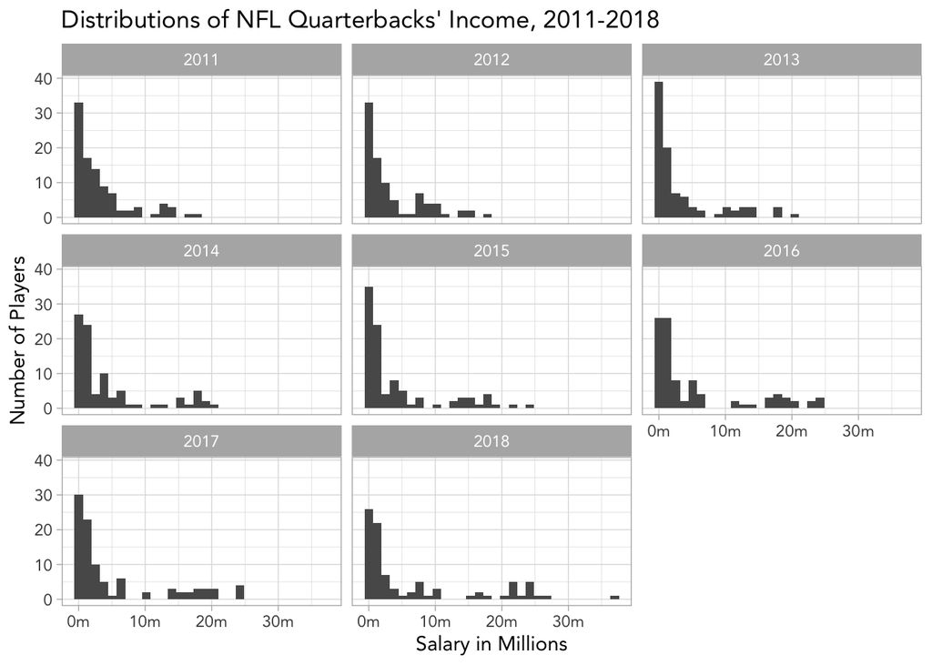

```r
nfl_salary_tidy %>%
  filter(position == "Quarterback") %>%
  ggplot(aes(salary)) +
  geom_histogram(nrow = 2) + # Not sure why this isn't adjusting to 2 rows?
  scale_x_continuous(labels = scales::label_number(suffix = "m", scale = 1e-6)) +
  facet_wrap(~ year) +
  labs(title = "Distributions of NFL Quarterbacks' Income, 2011-2018", x = "Salary in Millions", y = "Number of Players")
```

```r
# Trying to adjust scales of things but its a bit wonky. I need to do a piecewise sort of things where values less than 1 million are labeled more granularly and values over 1m are in 5 or 10 million
```

**The salary distribution for NFL quarterbacks, while always right skewed, is inching slightly towards less payers earning less and more players earning more.**

## Question 4

Average salary for each position each year

```r
average_sal_years <- nfl_salary_tidy %>%
  group_by(position, year) %>%
  summarize(avg_sal = mean(salary, na.rm = TRUE)) %>%
  arrange(desc(avg_sal))
# Checking missing values
#library(visdat)
#vis_dat(nfl_salary_tidy)
#vis_miss(nfl_salary_tidy)
```

## Question 5

```r
#mean(unlist(drop_na(nfl_salary_tidy[(nfl_salary_tidy[,"position"] == "Quarrback") & (nfl_salary_tidy[, "year"] == 2018), "salary"])))
```

Line graph of each positions average salary over time

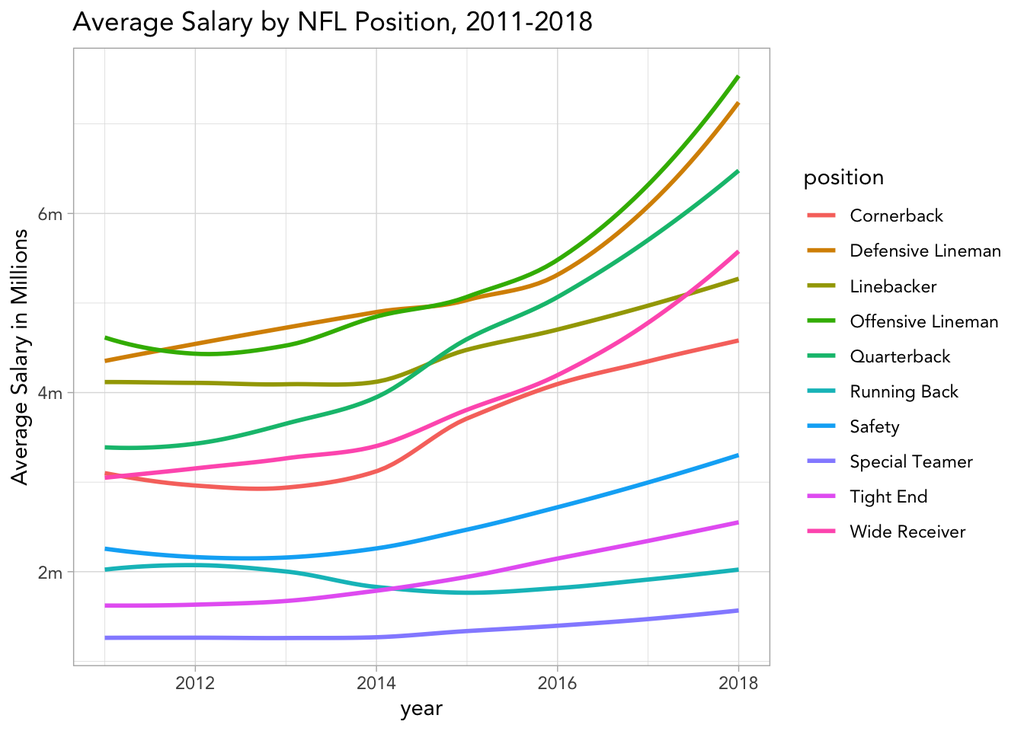

```r
average_sal_years %>%
  ggplot(aes(year, avg_sal, color = position)) +
  scale_y_continuous(labels = scales::label_number(suffix = "m", scale = 1e-6)) +
  labs(title = "Average Salary by NFL Position, 2011-2018", y = "Average Salary in Millions") +
  geom_smooth(size = 1, se = FALSE)
```

**We see that both offensive and defensive linemen have dominates earnings in this period, now earning upwards of $7 million on average. Notably, it appears that the average salary of running backs have actually decreased from 2012 to 2015 and their 2012 height in 2018**